# EP02-equipo-6

Gabriel Cabrera, Thomas Gustafsson, Vicente Rojas

2025-03-27

## Lectura del archivo csv:

```r
data = read.csv2("EP02 Datos(1).csv")
```

## PREGUNTA 1:

##### El Comité Olímpico cree que el mejor tiempo medio de los atletas de raza blanca antes de ingresar al programa de entrenamiento era 16,2 segundos. ¿Soportan los datos esta afirmación?

Se utilizará la prueba T DE STUDENT y un nivel de confianza igual a 0.05. El uso de esta prueba es porque la cantidad de observaciones son menores a 30, ya que es un requisito para utilizar en la prueba Z y por ende se descarta, y además no conocemos la desviación estandar.

Además se cúmplen las condiciones para utilizar la prueba T DE STUDENT, estos son: 1. Los tiempos de los atletas de raza blanca son independientes. 2. Provienen de una población normalmente distribuida.

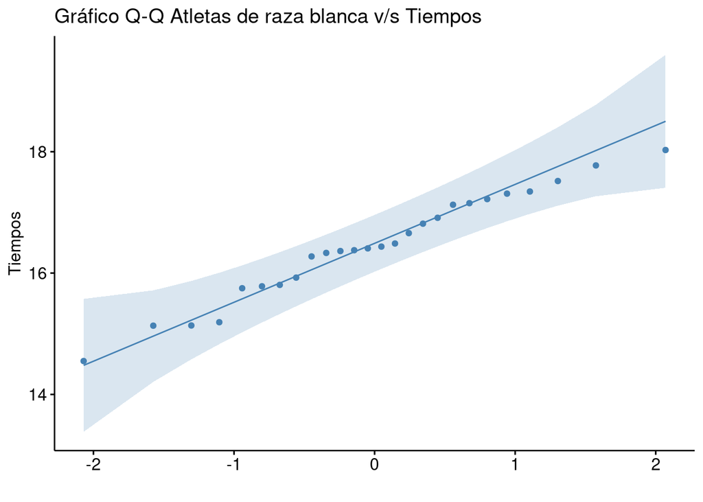

```r
#Filtramos los datos
blancos <- data[data$Raza == "Blanca",]

# Gráfica QQ-plot
g <- ggqqplot(data = data.frame(blancos),
              x = "Previo",
              color = "steelblue",
              xlab = "", ylab = "Tiempos",
              title = "Gráfico Q-Q Atletas de raza blanca v/s Tiempos")
print(g)
```

```r
# Prueba de normalidad de Shapiro-Wilk
shapiro.test(blancos$Previo)
```

```
##
##  Shapiro-Wilk normality test
##
## data:  blancos$Previo
## W = 0.97651, p-value = 0.7925
```

```r
#Comparar la media de la muestra con los 16,2 segundos.
prueba <- t.test(blancos$Previo, mu = 16.2, alternative = "two.sided")
print(prueba)
```

```
##
##  One Sample t-test
##
## data:  blancos$Previo
## t = 1.4769, df = 25, p-value = 0.1522
## alternative hypothesis: true mean is not equal to 16.2
## 95 percent confidence interval:
##  16.09988 16.80773
## sample estimates:
## mean of x
##  16.45381
```

## PREGUNTA 2:

##### ¿Sugieren los datos que la mejor marca de los atletas de raza oriental se reduce en promedio 4,7 segundos tras el entrenamiento?

```r
atl_oriental <- data %>% filter(Raza == "Oriental")

n = count(atl_oriental)

# Diferencia en los tiempos antes y después del entrenamiento
atl_oriental <- atl_oriental %>% mutate(Diferencia = Previo - Posterior)
```

Para contestar la pregunta primero debemos analizar la muestra y ver las condiciones que cumple, de este modo, sabremos que tipo de prueba se puede realizar: 1. Las observaciones son independientes, la elección de la muestra no influye con la selección de otras 2. Las observaciones provienen de una distribución normal 3. Se tiene 27 observaciones de la muestra

A continuación verificamos si se cumple el punto 2.

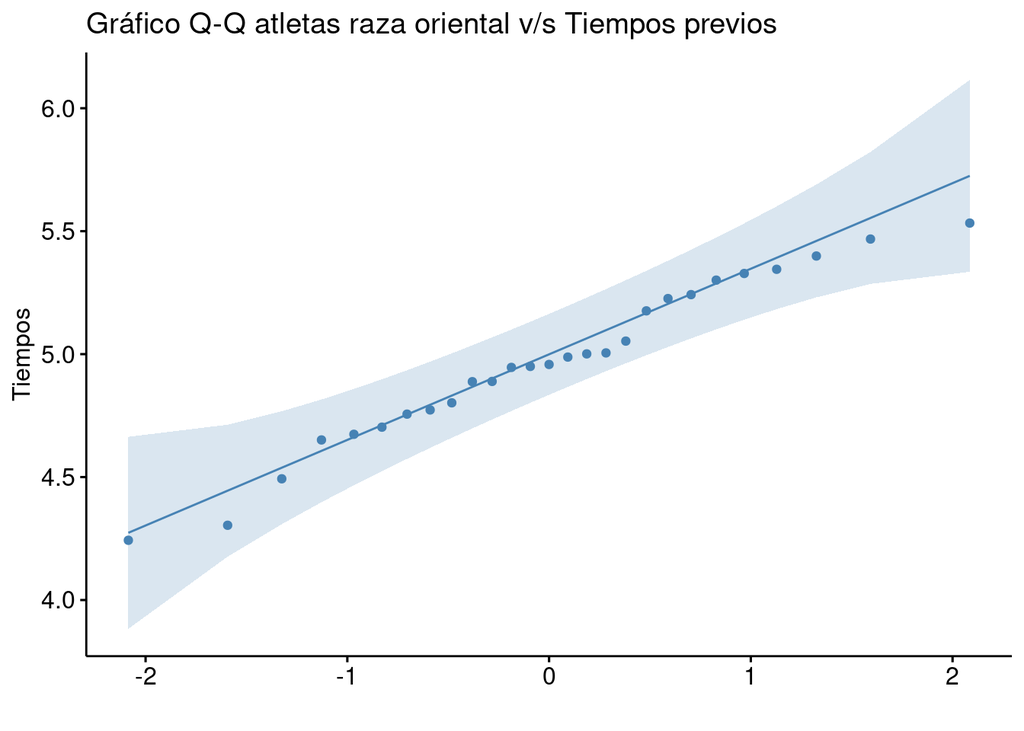

```r
g2 <- ggqqplot(data = data.frame(atl_oriental), x = "Diferencia",
                                color = "steelblue",
                                xlab = "", ylab = "Tiempos",
                                title = "Gráfico Q-Q atletas raza oriental v/s Tiempos previos")
print(g2)
```

```r
# Prueba de normalidad de Shapiro-Wilk
shapiro.test(atl_oriental$Diferencia)
```

```
##
##  Shapiro-Wilk normality test
##
## data:  atl_oriental$Diferencia
## W = 0.97305, p-value = 0.6839
```

Se utilizo la prueba de shapiro wilk, la cual indica que el valor p >= 0.05, por lo cual los datos siguen una distribución normal. Además, observando el gráfico Q-Q este indica que si siguen una distribuición normal.

Dadas las condiciones anteriores que se cumplen, podemos hacer uso de la prueba T de Student para una muestra, utilizando un nivel de confianza igual a 0.05.

Hipotesis nula, H0: Los datos sugieren que la mejor marca de los atletas de raza oriental se reduce en promedio 4.7 segundos tras el entrenamiento, por lo tanto, u_entrenamiento = 4.7

Hipótesis alternativa, HA: la reducción de la mejor marca de los atletas de raza oriental tras el entrenamiento es diferente de 4.7 segundos, por lo tanto, u_entrenamiento =/= 4.7

Se utiliza una prueba bilateral o de dos colas, debido a que se tiene que verificar si la reducción del tiempo es distinta, no solo si es mayor o menor.

```r
prueba2 <- t.test(atl_oriental$Diferencia, mu = 4.7, alternative = "two.sided", conf.level = 1-0.025)

print(prueba2)
```

```
##
##  One Sample t-test
##
## data:  atl_oriental$Diferencia
## t = 4.1419, df = 26, p-value = 0.0003227
## alternative hypothesis: true mean is not equal to 4.7
## 97.5 percent confidence interval:
##  4.813434 5.119529
## sample estimates:
## mean of x
##  4.966481
```

### RESPUESTA 2:

##### Luego de la realización de la prueba t student, el valor p = 0.0003227, por lo que se tiene que p < 0.05, indicando que rechazamos la hipótesis nula. Esto significa que la mejora promedio en los tiempos de los atletas orientales es diferente de 4.7 segundos. Sin embargo, como la media muestral entregada por la prueba t de student es mayor que 4.7, se puede concluir que la mejora en los tiempos es mayor a la esperada.

## PREGUNTA 3:

##### ¿Es posible afirmar que, en promedio, los atletas de raza negra superan a los de raza blanca por menos de 1 segundo después del entrenamiento?

### RESPUESTA 3:

##### Para responder la pregunta utlizamos el metodo de t student para 2 muestras independientes ya que corresponden a atletas de razas distintas y cuyos resultados no inciden en el tiempo de los otros. Antes de aplicar esta prueba se debe cumplir la condicion de que cada muestra cumple con una distribucion que tiende a ser normal, para esto aplicamos el test “shapiro.test”, este nos dira si esta condicion se cumple.

```r
atleta_negro <- data[data$Raza == "Negra", ]
atleta_blanco <- data[data$Raza == "Blanca", ]

atleta_negro_posterior <- atleta_negro$Posterior
atleta_blanco_posterior <- atleta_blanco$Posterior

normalidad_negro <- shapiro.test(atleta_negro_posterior)
normalidad_blanco <- shapiro.test(atleta_blanco_posterior)

print(normalidad_blanco)
```

```
##
##  Shapiro-Wilk normality test
##
## data:  atleta_blanco_posterior
## W = 0.94734, p-value = 0.2008
```

```r
print(normalidad_negro)
```

```
##
##  Shapiro-Wilk normality test
##
## data:  atleta_negro_posterior
## W = 0.95201, p-value = 0.2225
```

```r
t_test_resultado <- t.test(atleta_blanco_posterior, atleta_negro_posterior, alternative = "greater", mu = 1, var.equal = TRUE)

print (t_test_resultado)
```

```
##
##  Two Sample t-test
##
## data:  atleta_blanco_posterior and atleta_negro_posterior
## t = -0.58086, df = 52, p-value = 0.7181
## alternative hypothesis: true difference in means is greater than 1
## 95 percent confidence interval:
##  0.3005333       Inf
## sample estimates:
## mean of x mean of y
##  13.36719  12.54732
```